# Chicago Women in Big Data and Chicago R User Group

2019-06-11

## Local R News

## Data Science Workflows Using R and Spark

**Date - Friday, June 14th, 830a to 5p**

**Instructor - Dr. E. James Harner, West Virginia University**

**Location - Amazon Web Services, At&T Center, 227 W. Monroe, Suite 1400**

Information and Register here: https://www.123signup.com/event?id=rjmzb

## Lectures on Numerical Methods in Data Science

**Dates - June 17, 19, 21**

**Register by June 13**

https://cam.uchicago.edu/events/rtg/

The Committee on Computational and Applied Mathematics and the Department of Statistics will host a series of six lectures on “Numerical Methods in Data Science” by David Bindel of Cornell University and two seminars on deep neural networks by Julius Berner and Dennis Elbrachter of Vienna University.

## New Version of RUGtools

An R package containing data and functions to help organize the Chicago R User Group.

```r
library(RUGtools)
pizza_estimate(registered = 121, attend_rate = 0.55, pizza_diameter = 18)
```

```
##   registered est_attend eaters_per_pizza style pizza_estimate
## 1        121         67         5.342811  thin             13
```

## New Version of RUGtools

An R package containing data and functions to help organize the Chicago R User Group.

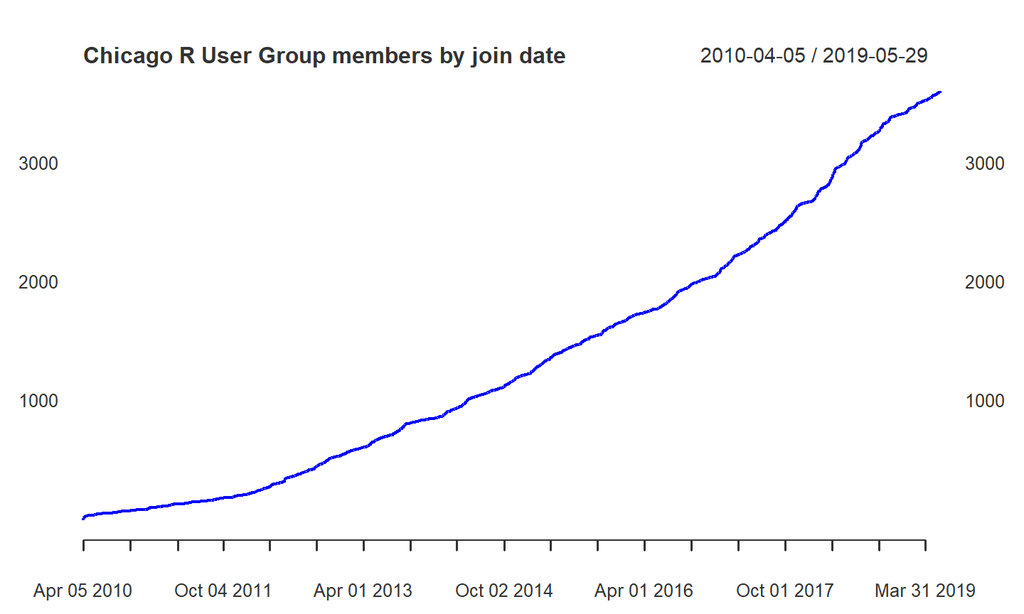

## Follow us

[Chicago-R-User-Group](https://twitter.com/ChicagoRusers)

@ChicagoRusers

## R Fortunes from the past

```r
fortunes::fortune()
```

```
##
## Either I am misunderstanding your intent or you need another cup of coffee.
##    -- Rolf Turner (in response to a user who did not understand his advice)
##       R-help (November 2013)
```

## Anyone hiring R folks?

## Today’s meetup and its Sponsor

## Welcoming Chicago Women in Big Data!

Follow us:

[Chicago-Women-in-Big-Data](https://www.meetup.com/Chicago-Women-in-Big-Data/)

ChiDataWomen

## Thank you IBM

## Thank you Gogo

[figure not shown]

## Today’s Feature

- **Developing credit risk models for recommendation engines** by Helen Ristov.
- **Analysis of Women’s National Basketball Association (WNBA) shot distributions with R** by Jonathan Mizel
- **Race for Data will be presented** by Amanda Mordacq

Thanks again to IBM and Gogo for sponsoring today’s meetup!